# Ejemplo documento R Markdown

M.A. Ibáñez y J. C. Martinez Àvila

# Introducción

Este es un documento R markdown en el que se explica como se puede crear un documento dinámico con R Markdown

Para poder crear documento dinamico con R Markdown hay que instalar el paquete `rmarkdown`

El siguiente código en R indica la instrucción que se debe ejecutar para instalar un paquete en R.

`install.packages("rmarkdown")`

Un paquete solo se instala en el ordenador una vez.

# Datos

Para este curso vamos a crear un carpeta que se llame `RegresionICE`.

En esa carpeta se van a guardar todos los archivos que se necesitan para seguir el curso.

Los archivos necesarios están en la siguiente dirección: https://github.com/ibruma/RegresionICE.git

Para descargar un archivo pulsar sobre el archivo y luego en la pestaña `Raw`. Descargar el archivo en la carpeta `RegresionICE` que se acaba de crear.

Una vez creada la carpeta se crea, asociada a la carpeta, un proyecto de Rstudio.

Para crear el proyecto se siguen los siguientes pasos:

- En el menú de Rstudio seleccionar `File/New Project..`.
- En la ventana emergente seleccionar la opción `Existing Direcory`
- En la siguiente ventana con el navegador se selecciona la carpeta `RegresionICE`

Pulsar en `Create Project`

## Importar Datos

En este ejemplo se va a trabajar con los datos del archivo `Purines_Metano2.xlsx` que es una hoja de datos en excel.

Para importar dichos datos y crear un marco de datos utilizaremos la función `read_xlsx()` del paquete `readxl`.

Si el paquete no está instalado lo instalamos utilizando la siguiente instrucción.

`install.packages("readxl")`

Para pode utilizar la función `read_xlsx()` hay que cargar en memoria el paquete utilizando la función `library()` tal y como se muestra en el siguiente código.

```r
## Carga en memoria el paquete readxl
library(readxl)
```

Ahora ya es posible importar el archivo de datos

```r
## Importar el archivo de datos Purines_Metano2.xls
Purines <- read_xlsx(path="Purines_Metano2.xlsx")
```

`Purines` es un marco de datos que tiene 79 filas y 4 columnas.

```r
knitr::kable(head(Purines),digits=2)
```

| FND | LAD | EE | CH4 |
| --- | --- | --- | --- |
| 17.34 | 4.46 | 11.87 | 429.91 |
| 44.77 | 9.59 | 11.38 | 155.30 |
| 26.37 | 4.24 | 16.09 | 413.37 |
| 51.10 | 14.41 | 5.99 | 115.06 |
| 59.63 | 14.10 | 7.19 | 169.95 |
| 24.37 | 5.43 | 5.87 | 177.24 |

## Análisis Estadístico

La siguiente figura muestra el gráfico de dispersión de la variable `CH4` frente a la variable `FND`.

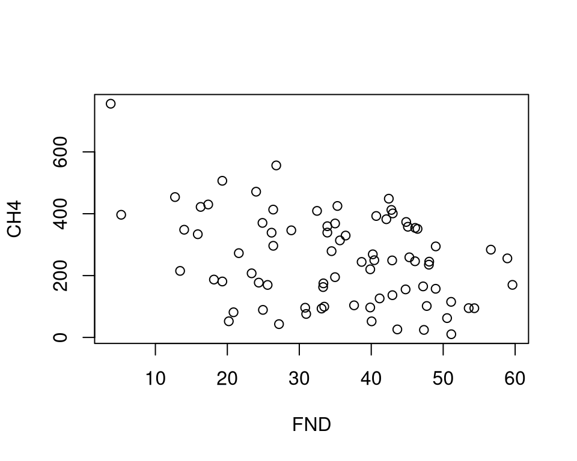

Gráfico de dispersión de CH4 frente a FND

```r
plot(CH4 ~ FND,data=Purines)
```

A continuación se estima el modelo de regresión lineal simple que relaciona la variable `CH4` con la variable `FND`.

```r
## Estima del modelo de regresión lineal simple
modelo <- lm(CH4 ~ FND,data=Purines)
## Resultado del modelo estimado
summary(modelo)
```

```
Call:
lm(formula = CH4 ~ FND, data = Purines)

Residuals:
    Min      1Q  Median      3Q     Max
-264.35 -112.43   17.55  101.05  370.70

Coefficients:
            Estimate Std. Error t value Pr(>|t|)
(Intercept)  400.885     45.595   8.792 3.01e-13 ***
FND           -4.174      1.219  -3.425 0.000989 ***
---
Signif. codes:  0 '***' 0.001 '**' 0.01 '*' 0.05 '.' 0.1 ' ' 1

Residual standard error: 136.3 on 77 degrees of freedom
Multiple R-squared:  0.1322,    Adjusted R-squared:  0.1209
F-statistic: 11.73 on 1 and 77 DF,  p-value: 0.0009889
```

A continuación se muestra el gráfico de dispersión junto con la recta de regresión estimada.

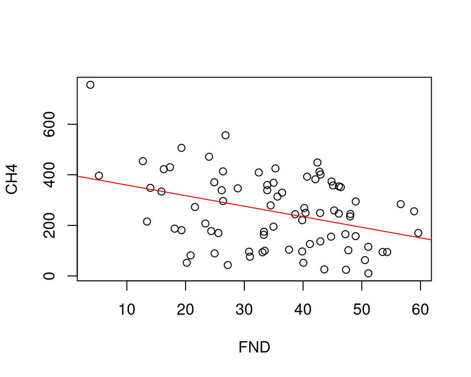

Gráfico de dispersión de CH4 frente a FND y recta de regresión estimada

```r
plot(CH4 ~ FND,data=Purines)
abline(modelo,lty=1,col="red")
```